# Reproduce analyses of Brennan and Collins 2015

Aurelie

# Introduction

This is a reproduction of an experiment presented in the paper *Growth responses of a green alga to multiple environmental drivers*, by Georgina Brennan and Sinead Collins ([the paper on the Nature website](http://www.nature.com/nclimate/journal/v5/n9/full/nclimate2682.html)). Details of the methods are in [the Supplementary Information to the Nature paper](http://www.nature.com/nclimate/journal/v5/n9/extref/nclimate2682-s1.pdf).

# Authors involved in this reproduction

Lead author was Aurélie Garnier. Ale teamed up too! All contributions are detailed on GitHub in the commit history.

# Goals for this reproduction

- Learn about Generalized Mixed Models (here, GAM).
- Personal interest of multiple environmental drivers (Aurélie).

# Known issues

The known issues/ problems with this reproduction are with the prefix “Brennan” ([here](https://github.com/opetchey/RREEBES/issues)). Please add or solved issues there.

# The data

The data are available on the [website](http://datadryad.org/resource/doi:10.5061/dryad.jt1fb) as CSV files, with text document referencing the content of the each CSV file.

- [**DataDryad_mixed_model_290415.csv**](http://datadryad.org/bitstream/handle/10255/dryad.86868/DataDryad_mixed_model_290415.csv?sequence=1). Raw data for mixed model analysis, plotting and creating case studies for further analysis. See read me section in r script “mixed_model_DataDryad_290415.r”.
- [**All_lines_030515.csv**](http://datadryad.org/bitstream/handle/10255/dryad.86870/All_lines_030515.csv?sequence=1). .csv file for plotting case study plot using r script “mixed_model_DataDryad_290415.r”.
- [**mixed_model_DataDryad_290415.r**](http://datadryad.org/bitstream/handle/10255/dryad.86871/mixed_model_DataDryad_290415.r?sequence=1). R script for mixed model analysis of raw data supplied and plotting.
- [**Simulation.r**](http://datadryad.org/bitstream/handle/10255/dryad.86872/Simulation.R?sequence=1). The effect of sampling from a finite number of possible environmental drivers was explored using a simulation written in R.

```r
rm(list=ls())
```

```r
library(RCurl) # can get URL link
```

```r
library(plyr) # function ddply
library(ggplot2) # plot
library(lme4)
```

# Get the raw data into R

```r
dd <- read.csv(text=getURL("http://datadryad.org/bitstream/handle/10255/dryad.86868/DataDryad_mixed_model_290415.csv?sequence=1"), check.names=FALSE)
str(dd)
```

```
## 'data.frame':    576 obs. of  24 variables:
##  $ ID              : Factor w/ 288 levels "1_A1","1_A2",..: 139 139 140 140 141 141 283 283 284 284 ...
##  $ treatment       : Factor w/ 96 levels "Co2","Co2/Herb",..: 49 49 49 49 49 49 1 1 1 1 ...
##  $ NED             : int  0 0 0 0 0 0 1 1 1 1 ...
##  $ regime          : int  49 49 49 49 49 49 1 1 1 1 ...
##  $ Temp            : Factor w/ 2 levels "no","yes": 1 1 1 1 1 1 1 1 1 1 ...
##  $ Co2             : Factor w/ 2 levels "no","yes": 1 1 1 1 1 1 2 2 2 2 ...
##  $ Herb            : Factor w/ 2 levels "no","yes": 1 1 1 1 1 1 1 1 1 1 ...
##  $ uv              : Factor w/ 2 levels "no","yes": 1 1 1 1 1 1 1 1 1 1 ...
##  $ Li              : Factor w/ 2 levels "no","yes": 1 1 1 1 1 1 1 1 1 1 ...
##  $ pH              : Factor w/ 2 levels "no","yes": 1 1 1 1 1 1 1 1 1 1 ...
##  $ ND              : Factor w/ 2 levels "no","yes": 1 1 1 1 1 1 1 1 1 1 ...
##  $ P               : Factor w/ 2 levels "no","yes": 1 1 1 1 1 1 1 1 1 1 ...
##  $ overlap         : num  0 0 0 0 0 0 0 0 0 0 ...
##  $ replicate       : int  1 1 2 2 3 3 4 4 5 5 ...
##  $ count.ml.Nt     : num  4062267 3878900 2956767 3894233 3233100 ...
##  $ logcount.Nt     : num  15.2 15.2 14.9 15.2 15 ...
##  $ count.ml.No     : num  301300 464700 270467 440200 450333 ...
##  $ logcount.No     : num  12.6 13 12.5 13 13 ...
##  $ Rate of Division: num  0.751 0.612 0.69 0.629 0.569 ...
##  $ risk.Extinction : num  0.922 0.987 0.98 0.97 1.106 ...
##  $ no.divisions    : num  3.75 3.06 3.45 3.15 2.84 ...
##  $ perDay          : num  0.751 0.612 0.69 0.629 0.569 ...
##  $ relative.fit    : num  1.121 1.023 1.03 1.051 0.849 ...
##  $ change.no.cells : num  752193 682840 537260 690807 556553 ...
```

# Figure 2

## Figure 2a

The figure 2a represents the mean and standard deviation between regimes for each NED.

```r
mean_per_regime <- ddply(.data=dd, .(regime,treatment), summarise, mean=mean(perDay),sd=sd(perDay))
mean_per_regime <- unique(merge(dd[,c("treatment","NED")], mean_per_regime, by="treatment"))
str(mean_per_regime)
```

```
## 'data.frame':    96 obs. of  5 variables:
##  $ treatment: Factor w/ 96 levels "Co2","Co2/Herb",..: 1 2 3 4 5 6 7 8 9 10 ...
##  $ NED      : int  1 2 3 4 5 6 7 2 2 7 ...
##  $ regime   : int  1 2 3 4 5 6 7 8 9 10 ...
##  $ mean     : num  0.56 0.451 0.511 0.46 0.578 ...
##  $ sd       : num  0.1783 0.0547 0.1568 0.1744 0.1309 ...
```

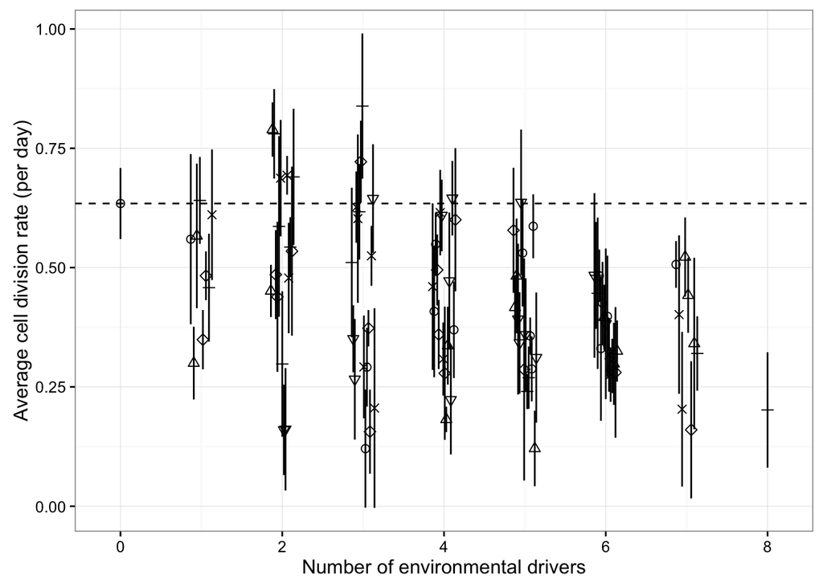

```r
pd <- position_dodge(width=0.3)
shape_treatment <- rep(c(1:6), 16)
lims <- aes(ymin=mean-sd, ymax=mean+sd)

fig2a <- ggplot(data=mean_per_regime, aes(x=NED, y=mean, group=treatment)) +
  geom_errorbar(lims, position = pd, width=0) +
  geom_point(aes(shape=treatment), position = pd, size=2) +
  scale_shape_manual(values=rep(c(1:6),16)) +
  geom_hline(aes(yintercept=mean_per_regime[which(mean_per_regime$NED==0),"mean"]), linetype=2) +
  labs(x="Number of environmental drivers", y="Average cell division rate (per day)") +
  theme_bw()+
  theme(legend.position="none")
fig2a
```

If problem with position_dodge(), it needs a grouping variable (here, “treatment”)

## The need for overlaping and its estimation

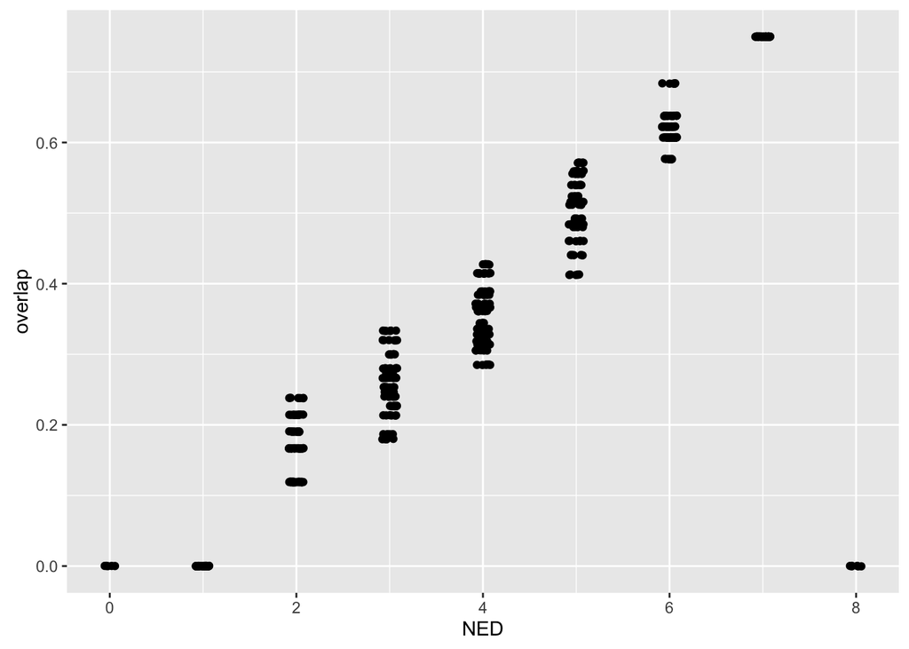

```r
ggplot(data=dd, aes(x=NED, y=overlap)) +
  geom_jitter(width=0.2)
```

The need of estimating the overlap of NED between regimes is due to the experimental design. In this study not all possible combination between environmental drivers (which would be 2^8=256 combinations, whereas here 96 combinations were tested). Then, the overlap take into account that some environmental drivers are often involved than others. The estimation of overlap was directly in the data sheet.

The overlap is the number of times that each drivers involved in a specific regime is involved in other regimes, given the total number of possible combinations and the number of combinations realized.

for example in the combination CO2/Herb. The overlap is 0.166667. The driver “CO2” appears 7 times (in 2-way factorial combinations) and “Herb” appears 2 times. If all possible 2 way combinations were done, there should have 28 regimes but only 15 were done in the experiment. ((7-1)+(2-1)/28) / 15 = 0.0166667

… but I consistently found a factor of 1/10 between the given overlap and the estimated overlap. It might be a choice from the authors to multiple all the overlap by a factor 10 (which shoud not change the effect)

## The relative fit

This measurement is used to estimate as the effect of each regime.

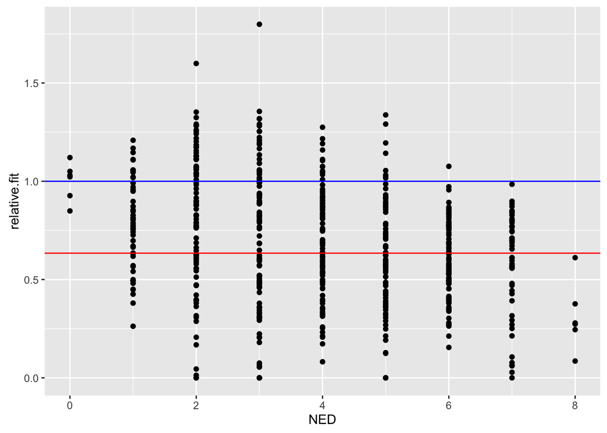

```r
ggplot(data=dd, aes(x=NED,y=relative.fit)) + geom_point() +
  geom_hline(yintercept = mean_per_regime[which(mean_per_regime$NED=="0"),"mean"], colour="red" )+
  geom_hline(yintercept = 1, colour="blue")
```

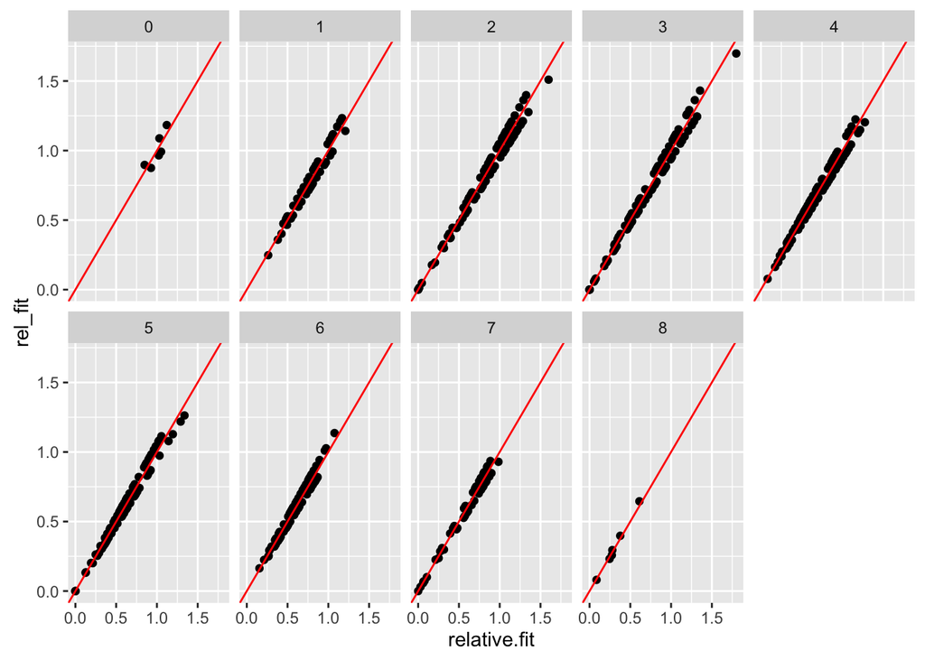

```r
test_relative <- dd
test_relative$rel_fit <- test_relative$perDay /mean_per_regime[which(mean_per_regime$NED=="0"),"mean"]

ggplot(data=test_relative, aes(relative.fit, rel_fit)) + geom_point() +
  geom_abline(intercept = 0, slope = 1, colour="red") +
  facet_wrap(~NED, nrow = 2)
```

## Fig 2b-c-d

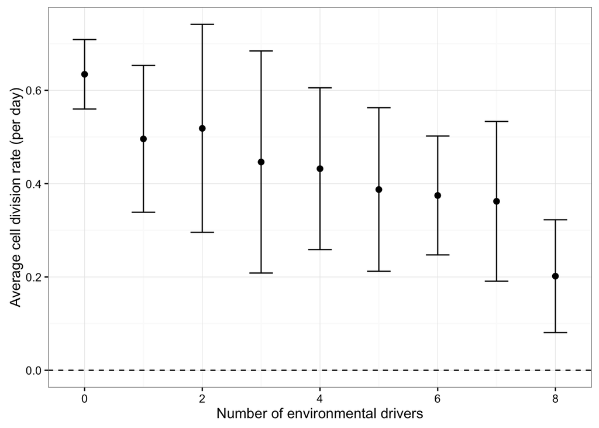

```r
mean_per_NED <- ddply(.data=dd, .(NED), summarise,
                      mean=mean(perDay), sd=sd(perDay))

fig2_base <- ggplot(data=mean_per_NED, aes(x=NED, y=mean)) +
  geom_errorbar(aes(x=NED, ymax=mean+sd, ymin=mean-sd),width=.4) +
  geom_point(size=2) +
  geom_hline(aes(yintercept=0), linetype=2) +
  labs(x="Number of environmental drivers", y="Average cell division rate (per day)") +
  theme_bw()+
  theme(legend.position="none")
fig2_base
```

```r
mod1 <- lmer(perDay ~ NED + overlap + (1|regime) + (1|replicate), REML=TRUE, data=dd)
summary(mod1)
```

```
## Linear mixed model fit by REML ['lmerMod']
## Formula: perDay ~ NED + overlap + (1 | regime) + (1 | replicate)
##    Data: dd
##
## REML criterion at convergence: -611.4
##
## Scaled residuals:
##      Min       1Q   Median       3Q      Max
## -2.81385 -0.52053  0.03997  0.61275  2.63327
##
## Random effects:
##  Groups    Name        Variance  Std.Dev.
##  replicate (Intercept) 0.0008994 0.02999
##  regime    (Intercept) 0.0207555 0.14407
##  Residual              0.0127213 0.11279
## Number of obs: 576, groups:  replicate, 288; regime, 96
##
## Fixed effects:
##             Estimate Std. Error t value
## (Intercept)  0.57623    0.03857  14.942
## NED         -0.06676    0.01997  -3.343
## overlap      0.32863    0.16691   1.969
##
## Correlation of Fixed Effects:
##         (Intr) NED
## NED     -0.620
## overlap  0.279 -0.907
```

```r
anova(mod1)
```

```
## Analysis of Variance Table
##         Df   Sum Sq  Mean Sq F value
## NED      1 0.174091 0.174091 13.6850
## overlap  1 0.049316 0.049316  3.8766
```

```r
mod2<- lmer (perDay ~ NED + overlap + (1|Co2) + (1|Temp) + (1|pH) + (1|P) + (1|Herb) + (1|uv) + (1|ND) + (1|Li) + (1|replicate), dd)
summary(mod2)
```

```
## Linear mixed model fit by REML ['lmerMod']
## Formula: perDay ~ NED + overlap + (1 | Co2) + (1 | Temp) + (1 | pH) +
##     (1 | P) + (1 | Herb) + (1 | uv) + (1 | ND) + (1 | Li) + (1 |
##     replicate)
##    Data: dd
##
## REML criterion at convergence: -544.5
##
## Scaled residuals:
##      Min       1Q   Median       3Q      Max
## -2.56632 -0.49994  0.00397  0.52902  2.17051
##
## Random effects:
##  Groups    Name        Variance Std.Dev.
##  replicate (Intercept) 0.011985 0.10948
##  Li        (Intercept) 0.000000 0.00000
##  ND        (Intercept) 0.000000 0.00000
##  uv        (Intercept) 0.002220 0.04712
##  Herb      (Intercept) 0.002709 0.05205
##  P         (Intercept) 0.006527 0.08079
##  pH        (Intercept) 0.000000 0.00000
##  Temp      (Intercept) 0.000000 0.00000
##  Co2       (Intercept) 0.007081 0.08415
##  Residual              0.012721 0.11279
## Number of obs: 576, groups:
## replicate, 288; Li, 2; ND, 2; uv, 2; Herb, 2; P, 2; pH, 2; Temp, 2; Co2, 2
##
## Fixed effects:
##             Estimate Std. Error t value
## (Intercept)  0.52261    0.10076   5.187
## NED         -0.04893    0.01170  -4.182
## overlap      0.23856    0.08725   2.734
##
## Correlation of Fixed Effects:
##         (Intr) NED
## NED     -0.211
## overlap  0.052 -0.792
```

```r
anova(mod2)
```

```
## Analysis of Variance Table
##         Df   Sum Sq  Mean Sq F value
## NED      1 0.138750 0.138750 10.9069
## overlap  1 0.095103 0.095103  7.4759
```

```r
# two possibilities to get the main effects

## 1/ using the mean when NED = 1
main_effect_1 <- ddply(subset(dd, NED==1|NED==0), .(treatment,NED), summarise,
                       mean=mean(perDay),
                       sd=sd(perDay),
                       var=var(perDay))

## 2/ using the estimates of the linear model (possible because two levels of each driver, and one of which is the control)
mod_main_effect <- lm(perDay ~ Temp+Co2+Herb+uv+Li+pH+ND+P, subset(dd, NED==1 | NED==0))
summary(mod_main_effect)
```

```
##
## Call:
## lm(formula = perDay ~ Temp + Co2 + Herb + uv + Li + pH + ND +
##     P, data = subset(dd, NED == 1 | NED == 0))
##
## Residuals:
##      Min       1Q   Median       3Q      Max
## -0.33188 -0.06473 -0.00490  0.06902  0.21606
##
## Coefficients:
##              Estimate Std. Error t value Pr(>|t|)
## (Intercept)  0.634291   0.045613  13.906  < 2e-16 ***
## Tempyes     -0.176317   0.064507  -2.733  0.00893 **
## Co2yes      -0.074740   0.064507  -1.159  0.25272
## Herbyes     -0.334434   0.064507  -5.184 4.97e-06 ***
## uvyes       -0.023551   0.064507  -0.365  0.71675
## Liyes       -0.067965   0.064507  -1.054  0.29769
## pHyes       -0.151423   0.064507  -2.347  0.02336 *
## NDyes        0.006507   0.064507   0.101  0.92010
## Pyes        -0.285314   0.064507  -4.423 6.10e-05 ***
## ---
## Signif. codes:  0 '***' 0.001 '**' 0.01 '*' 0.05 '.' 0.1 ' ' 1
##
## Residual standard error: 0.1117 on 45 degrees of freedom
## Multiple R-squared:  0.5655, Adjusted R-squared:  0.4882
## F-statistic: 7.321 on 8 and 45 DF,  p-value: 3.499e-06
```

```r
est_main_effect <- data.frame(coefficients(mod_main_effect))
est_main_effect$treatment <- gsub("yes","",row.names(est_main_effect))
row.names(est_main_effect) <- NULL
names(est_main_effect)[1] <- "estimate"

## predict the value (Intercept + effect) to compare with the "main_effect_1"
main_effect_2 <- ddply(est_main_effect, .(treatment), summarise,
                           pred = est_main_effect[1,1] + estimate)

# --> Both method give the same answer
```

Script for the prediction data according to hypothesis

```r
dd_fig2 <- dd[,c(2:12)]

##replace NA for estimates
dd_fig2$Temp <- ifelse(dd_fig2$Temp=="yes",
                   est_main_effect[which(est_main_effect$treatment=="Temp"),"estimate"],
                   NA)
dd_fig2$Co2 <- ifelse(dd_fig2$Co2=="yes",
                   est_main_effect[which(est_main_effect$treatment=="Co2"),"estimate"],
                   NA)
dd_fig2$Herb <- ifelse(dd_fig2$Herb=="yes",
                   est_main_effect[which(est_main_effect$treatment=="Herb"),"estimate"],
                   NA)
dd_fig2$uv <- ifelse(dd_fig2$uv=="yes",
                   est_main_effect[which(est_main_effect$treatment=="uv"),"estimate"],
                   NA)
dd_fig2$Li <- ifelse(dd_fig2$Li=="yes",
                   est_main_effect[which(est_main_effect$treatment=="Li"),"estimate"],
                   NA)
dd_fig2$pH <- ifelse(dd_fig2$pH=="yes",
                   est_main_effect[which(est_main_effect$treatment=="pH"),"estimate"],
                   NA)
dd_fig2$ND <- ifelse(dd_fig2$ND=="yes",
                   est_main_effect[which(est_main_effect$treatment=="ND"),"estimate"],
                   NA)
dd_fig2$P <- ifelse(dd_fig2$P=="yes",
                   est_main_effect[which(est_main_effect$treatment=="P"),"estimate"],
                   NA)
dd_fig2 <- unique(dd_fig2)
```